# Dohyun Kang's visualization project

- Hello, this is Dohyun Kang's visualization project using Jupyter Notebook, conduct on February, 2023
- This analysis is created solely for Dohyun kang's project to demonstrate an ability to pull, organize and visualize data via codes.
- If you want to see all codes about this project, please go to Michelin data.ipynb file
- DATA is based on January 2023 Michelin Guide data from kaggle.com

# Michelin star-rated restaurant

- Number of Michelin star-rated restaurnts by country and city
- Number of Michelin three star-rated restaurants by country and city
- Michelin star-rated restaurants in USA
  - Contemporary or traditional style in USA
  - Base cuisine of contemporary style Michelin star-rated restaurants in USA
  - Traditional style Michelin star-rated restaurants in USA
  - Vegetarian Michelin star-rated restaurant in USA
- QA

## How many Michelin star-rated restaurants are there worldwide?

### Answer: 3,369

## Top 23 countries with the most number of Michelin star-rated restaurants

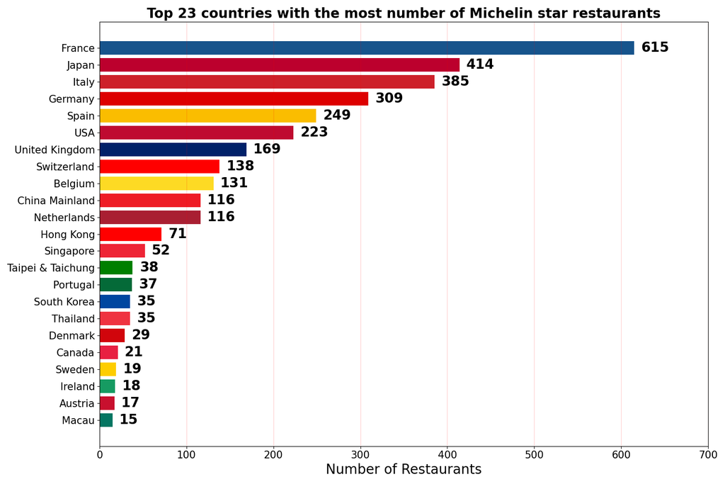

- France has the most Michelin star-rated restaurants in the world with a total of 615 restaurants.
- The majority of Michelin restaurants are located in Europe.
- Interestingly, Japan is the only country compete against European countries in top 5.
- USA ranked 6th with a total of 223 restaurants.

### Fun fact

Michelin Guide was started by the Michelin tire company to entertain people while going on a road trip. As people started owning more cars, they wanted to drive somewhere, but they didn't know where to go. Michelin company started issuing Michelin guide book to provide people with destinations. At that time, a one star-rated restaurant was considered worthy to stop by.

## Top 23 cities with the most number of Michelin star-rated restaurants

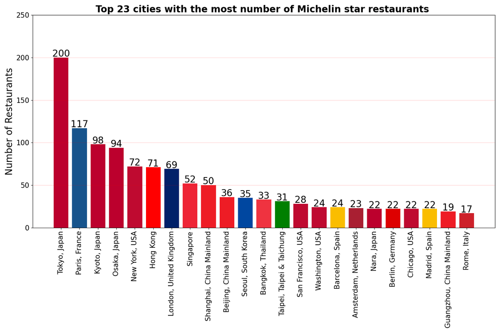

- Japan has several cities ranked in top 5.
- Tokyo has the most star-rated restaurants with 200 restaurants.
- Paris is ranked second with 117 restaurants in the city.
- New York is ranked 5th city in the world.

## How many number of Michelin three star-rated restaurants in the world?

### Answer: 142

[figure not shown]

- France has the most Michelin three star-rated restaurants in the world
- Japan is ranked 2nd, followed by USA.

## Fun fact

- Some people say that dining at the three star-rated Michelin restaurants is a lifetime experience. Others think that the price of those restaurants are too overpriced and it is not worth to go.

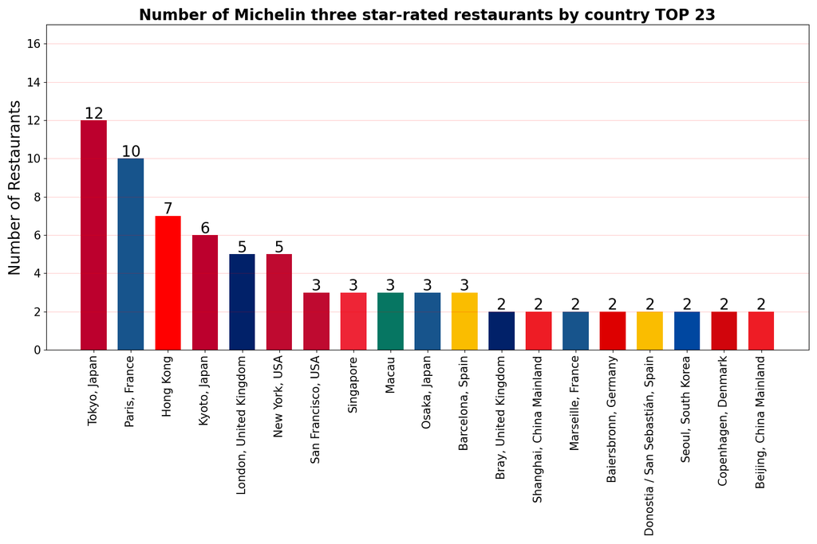

- Tokyo has the most Michelin three star-rated restaurants in the world, followed by Paris.
- Surprisingly, Hong Kong is ranked 3rd. Hong kong was never listed under top 5 the previous charts above.

### Dohyun Kang at a three star-rated restaurant

While DK was attending culinary school, he was interning at three star-rated restaurant in San Francisco called Quince. He successfully ened his intern, and went back to school

# Michelin star-rated restaruants in USA

## How many Michelin star-rated restaurants in USA?

### Answer: 223

## USA Michelin star Contemporary vs Traditional

### What is contemporary style?

It is basically non-traditional style which is focusing on modern technique, creativity, fusion,and innovation.

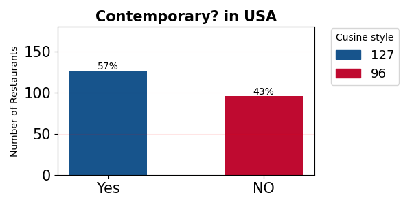

- There are more contemporary style Michelin star-rated restaurants than traditional style.

### Most contemporary style restaurants still focus on certain cuisine as a basis

[figure not shown]

- 17% of contemporary Michelin star-rated restaurants are based on American cuisine
- 14% of contemporary Michelin star-rated restaurants are based on Fremch cuisine

[figure not shown]

### NOTE

- ETC group contains: Chinese, Colombian, European, Filipino, Vegetarian. There is only one restaurant for each cuisine.
- If restaurants is listed just contemporary without specified cuisine in the data, they are in contemporary group.

## Traditional style Michelin star-rated restaurants in US

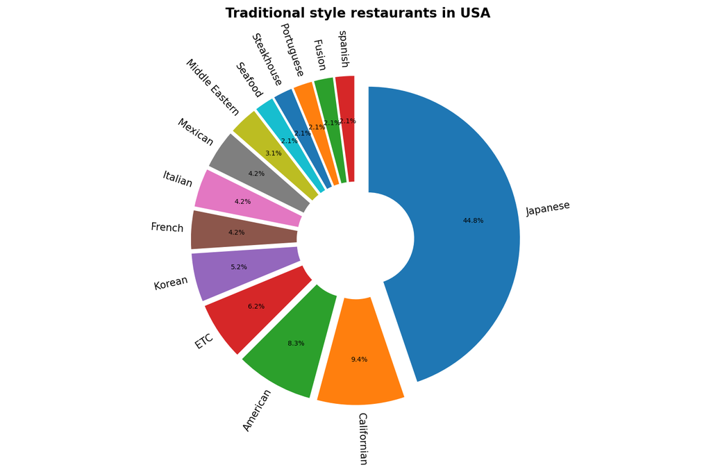

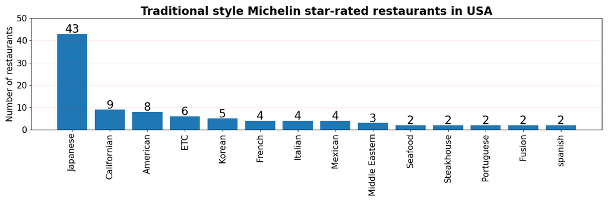

- 43 Michelin star-rated restaurants serve traditional Japanese cuisine
- About 45 % of total tradition style Michelin star-rated restaurants serve Japanese cuisine

### Note :

- Thai, Vegetarian, Asian, Indian, Colombian, Latin American restaurants are included in ETC group.
- Seafood, steakhouse, Fuison groups in the chart didn't specify which cuisine they serve.

## Vegetarian Michelin star-rated restaurants in USA

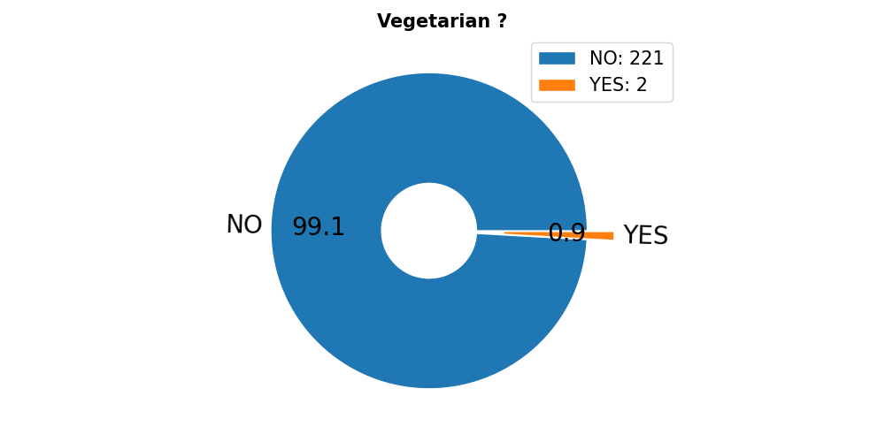

## Many michelin star restaurant may have vegetarian or vegan option for customer. However, How many Michelin star-rated restaurants in USA are mainly serving vegetarian dish?

- There are only 2 restaurants in USA.
  - Dirt Candy 86 Allen St., New York, 10002, USA
  - Oyster Oyster 1440 8th St., Washington D.C, 20001, USA

# QA

## The closest Michelin star-rated restaurants from Washington state

- Sadly, closest Michelin star-rated restaurants in US from Washington state is California.
- Vancouver, Canada have eight michelin star-rated restaurants
- List of Michelin star-rated restaurants in Vancouver, Canada

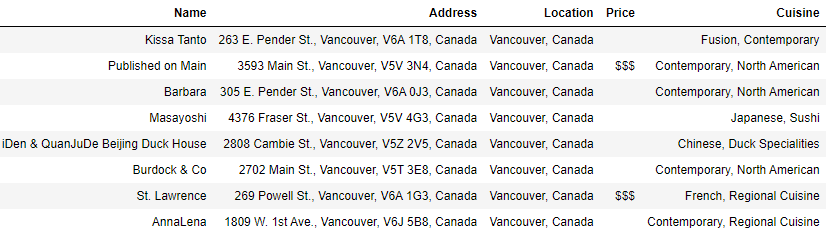

## How many restaurants are listed with a single "$" sign in USA

### Answer: 41

## What is the northernmost Michelin star-rated restaurant in the world?

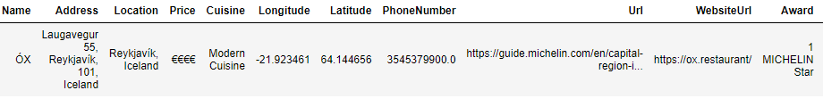

### Answer

- Name: ÓX
- Address: Laugavegur 55, Reykjavík, 101, Iceland
- Location: Reykjavík, Iceland
- Price: €€€€
- Cuisine: Modern Cuisine
- Longitude: -21.923461
- Latitude: 64.144656
- PhoneNumber: 3545379900.0
- Url: https://guide.michelin.com/en/capital-region-i...
- WebsiteUrl: https://ox.restaurant/
- Award: 1 MICHELIN Star

## What is the southernmost Michelin star-rated restaurant in the world

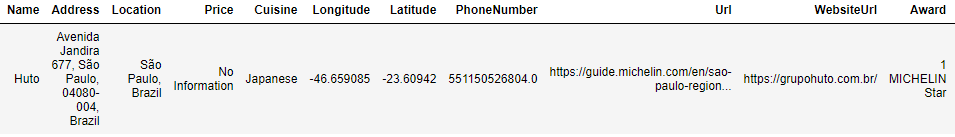

### Answer

- Name: Huto
- Address: Avenida Jandira 677, São Paulo, 04080-004, Brazil
- Location: São Paulo, Brazil
- Price: No Information
- Cuisine: Japanese
- Longitude: -46.659085
- Latitude: -23.60942
- PhoneNumber: 551150526804.0
- Url: https://guide.michelin.com/en/sao-paulo-region...
- WebsiteUrl: https://grupohuto.com.br/
- Award: 1 MICHELIN Star

## How many Michelin star-rated restaurants are specialized in Japanese cuisine in France?

- There are 7 Michelin Japanese restaurant in France.

[figure not shown]

## How many Michelin star-rated restaurants are specialized in French cuisine in Japan?

- There are 76 Michelin star-rated restaurants serving French cuisine in Japan.

# How many Michelin star-rated restaurants serve French, Japanese, Korean or American?

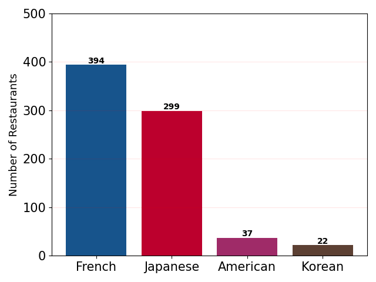

- There are 394 Michelin star-rated restaurants serve French cuisine.
- There are 299 Michelin star-rated restaurants serve Japanese cuisine.
- There are 37 Michelin star-rated restaurants serve American cuisine.
- There are 22 Michelin star-rated restaurants serve Korean cuisine.